# Project_EDA

Prognozowanie cukrzycy

Tomasz Sałapatek

2023-12-02

# Wstęp

Tematem mojego zestawu statystycznego jest baza “Diabetes prediction dataset”. Kręci się ona wokół danych pacjentów. Głównym tematem badań była próba ustalenia co może wskazać na to, że dana osoba ma cukrzycę. Naturalnie w takim razie, będę głównie zadawał pytania badawcze związane z genezą zestawu.  
Zestaw składa się z 100 000 obserwacji oraz 9 zmiennych, w dalszej części pliku zajmę się ich omawianiem.

Na początku wgrywam plik z bazą danych

```r
library(readr)
diabetes_prediction_dataset <- read_csv("diabetes_prediction_dataset.csv")
```

Przypisuje do zmiennej C, aby w przyszłości prościej było się odwoływać. (C od cukrzyca)

```r
C <- diabetes_prediction_dataset
```

Dodaje potrzebne biblioteki

```r
library(tidyverse)
```

```r
library(dplyr)
library(ggplot2)
library(gapminder)
library(CGPfunctions)
library(psych)
library(mice)
library(corrplot)
library(knitr)
```

```r
library(vcd)
```

Przeglądam kilka wartości oraz poddaje podstawowej analizie

```r
head(C)
```

```
## # A tibble: 6 × 9
##   gender   age hypertension heart_disease smoking_history   bmi HbA1c_level
##   <chr>  <dbl>        <dbl>         <dbl> <chr>           <dbl>       <dbl>
## 1 Female    80            0             1 never            25.2         6.6
## 2 Female    54            0             0 No Info          27.3         6.6
## 3 Male      28            0             0 never            27.3         5.7
## 4 Female    36            0             0 current          23.4         5
## 5 Male      76            1             1 current          20.1         4.8
## 6 Female    20            0             0 never            27.3         6.6
## # ℹ 2 more variables: blood_glucose_level <dbl>, diabetes <dbl>
```

```r
tail(C)
```

```
## # A tibble: 6 × 9
##   gender   age hypertension heart_disease smoking_history   bmi HbA1c_level
##   <chr>  <dbl>        <dbl>         <dbl> <chr>           <dbl>       <dbl>
## 1 Female    36            0             0 No Info          24.6         4.8
## 2 Female    80            0             0 No Info          27.3         6.2
## 3 Female     2            0             0 No Info          17.4         6.5
## 4 Male      66            0             0 former           27.8         5.7
## 5 Female    24            0             0 never            35.4         4
## 6 Female    57            0             0 current          22.4         6.6
## # ℹ 2 more variables: blood_glucose_level <dbl>, diabetes <dbl>
```

```r
summary(C)
```

```
##     gender               age         hypertension     heart_disease
##  Length:100000      Min.   : 0.08   Min.   :0.00000   Min.   :0.00000
##  Class :character   1st Qu.:24.00   1st Qu.:0.00000   1st Qu.:0.00000
##  Mode  :character   Median :43.00   Median :0.00000   Median :0.00000
##                     Mean   :41.89   Mean   :0.07485   Mean   :0.03942
##                     3rd Qu.:60.00   3rd Qu.:0.00000   3rd Qu.:0.00000
##                     Max.   :80.00   Max.   :1.00000   Max.   :1.00000
##  smoking_history         bmi         HbA1c_level    blood_glucose_level
##  Length:100000      Min.   :10.01   Min.   :3.500   Min.   : 80.0
##  Class :character   1st Qu.:23.63   1st Qu.:4.800   1st Qu.:100.0
##  Mode  :character   Median :27.32   Median :5.800   Median :140.0
##                     Mean   :27.32   Mean   :5.528   Mean   :138.1
##                     3rd Qu.:29.58   3rd Qu.:6.200   3rd Qu.:159.0
##                     Max.   :95.69   Max.   :9.000   Max.   :300.0
##     diabetes
##  Min.   :0.000
##  1st Qu.:0.000
##  Median :0.000
##  Mean   :0.085
##  3rd Qu.:0.000
##  Max.   :1.000
```

```r
str(C)
```

```
## spc_tbl_ [100,000 × 9] (S3: spec_tbl_df/tbl_df/tbl/data.frame)
##  $ gender             : chr [1:100000] "Female" "Female" "Male" "Female" ...
##  $ age                : num [1:100000] 80 54 28 36 76 20 44 79 42 32 ...
##  $ hypertension       : num [1:100000] 0 0 0 0 1 0 0 0 0 0 ...
##  $ heart_disease      : num [1:100000] 1 0 0 0 1 0 0 0 0 0 ...
##  $ smoking_history    : chr [1:100000] "never" "No Info" "never" "current" ...
##  $ bmi                : num [1:100000] 25.2 27.3 27.3 23.4 20.1 ...
##  $ HbA1c_level        : num [1:100000] 6.6 6.6 5.7 5 4.8 6.6 6.5 5.7 4.8 5 ...
##  $ blood_glucose_level: num [1:100000] 140 80 158 155 155 85 200 85 145 100 ...
##  $ diabetes           : num [1:100000] 0 0 0 0 0 0 1 0 0 0 ...
##  - attr(*, "spec")=
##   .. cols(
##   ..   gender = col_character(),
##   ..   age = col_double(),
##   ..   hypertension = col_double(),
##   ..   heart_disease = col_double(),
##   ..   smoking_history = col_character(),
##   ..   bmi = col_double(),
##   ..   HbA1c_level = col_double(),
##   ..   blood_glucose_level = col_double(),
##   ..   diabetes = col_double()
##   .. )
##  - attr(*, "problems")=<externalptr>
```

```r
describe(C)
```

```
##                     vars     n   mean    sd median trimmed   mad   min    max
## gender*                1 1e+05   1.41  0.49   1.00    1.39  0.00  1.00   3.00
## age                    2 1e+05  41.89 22.52  43.00   42.00 26.69  0.08  80.00
## hypertension           3 1e+05   0.07  0.26   0.00    0.00  0.00  0.00   1.00
## heart_disease          4 1e+05   0.04  0.19   0.00    0.00  0.00  0.00   1.00
## smoking_history*       5 1e+05   4.03  1.31   4.00    4.20  1.48  1.00   6.00
## bmi                    6 1e+05  27.32  6.64  27.32   26.91  4.51 10.01  95.69
## HbA1c_level            7 1e+05   5.53  1.07   5.80    5.57  1.19  3.50   9.00
## blood_glucose_level    8 1e+05 138.06 40.71 140.00  134.88 28.17 80.00 300.00
## diabetes               9 1e+05   0.09  0.28   0.00    0.00  0.00  0.00   1.00
##                      range  skew kurtosis   se
## gender*               2.00  0.35    -1.86 0.00
## age                  79.92 -0.05    -1.00 0.07
## hypertension          1.00  3.23     8.44 0.00
## heart_disease         1.00  4.73    20.41 0.00
## smoking_history*      5.00 -1.00     0.42 0.00
## bmi                  85.68  1.04     3.52 0.02
## HbA1c_level           5.50 -0.07     0.22 0.00
## blood_glucose_level 220.00  0.82     1.74 0.13
## diabetes              1.00  2.98     6.86 0.00
```

# Przygotowanie danych oraz ich ogląd

Po zapoznaniu się z danymi, bardzo łatwo nam zauważyć, że niektóre z nich zapisane są słownie. Wygodnie dla nas byłoby zamienić je na faktory.

```r
C$gender <- as.factor(C$gender)
C$smoking_history <-as.factor(C$smoking_history)
```

Następnie pochylmy się nad statystykami hypertension, heart_disease oraz diabetes, zmienne te choć podane numerycznie przyjmują wartości od 0 do 1, więc zamienimy je również na faktory

```r
C$hypertension <- as.factor(C$hypertension)
levels(C$hypertension) <- c("Brak nadciśnienia","Nadciśnienie")
C$heart_disease <- as.factor(C$heart_disease)
levels(C$heart_disease) <-c("Brak choroby serca", "Chory na chorobę serca")
C$diabetes <- as.factor(C$diabetes)
levels(C$diabetes)<-c("Brak Cukrzycy","Chory na cukrzycę")
```

Skoro mamy już uporządkowane zmienne do typów które powinny mieć, przyjrzyjmy się każdej z kolei

Zmienna płęć - zm. jakościowa, która ma 3 wartości {female,male,other}

```r
table(C$gender)
```

```
##
## Female   Male  Other
##  58552  41430     18
```

Zobaczmy odrazu jak to się ma na wykresie:

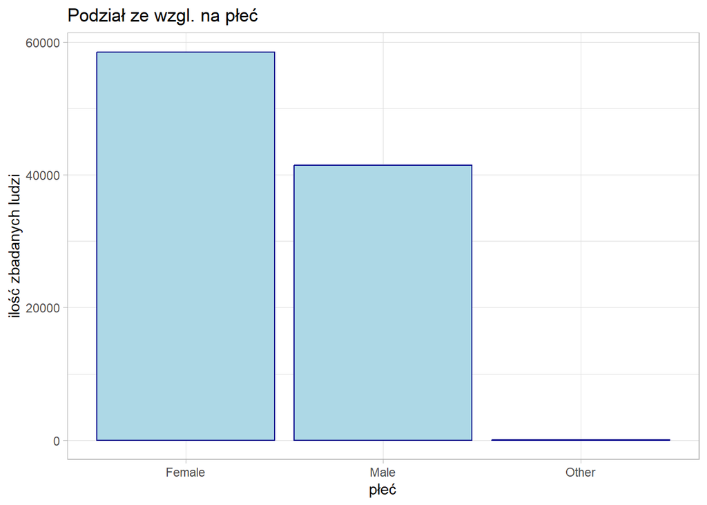

```r
C %>%
  ggplot() +
  geom_bar(aes(x = gender),
           color = "darkblue", fill = "lightblue") +
  theme_light() +
  labs(title = "Podział ze wzgl. na płeć",
       x = "płeć",
       y = "ilość zbadanych ludzi")
```

Zarówno w tabeli jak i po spojrzeniu na wykres możemy stwierdzić, że większość przebadanych osób to kobiety, a wyjątki (others) stanowią astronomicznie małą część badanej próbki.

Kolejną zmienną jest age (wiek):

```r
summary(C$age)
```

```
##    Min. 1st Qu.  Median    Mean 3rd Qu.    Max.
##    0.08   24.00   43.00   41.89   60.00   80.00
```

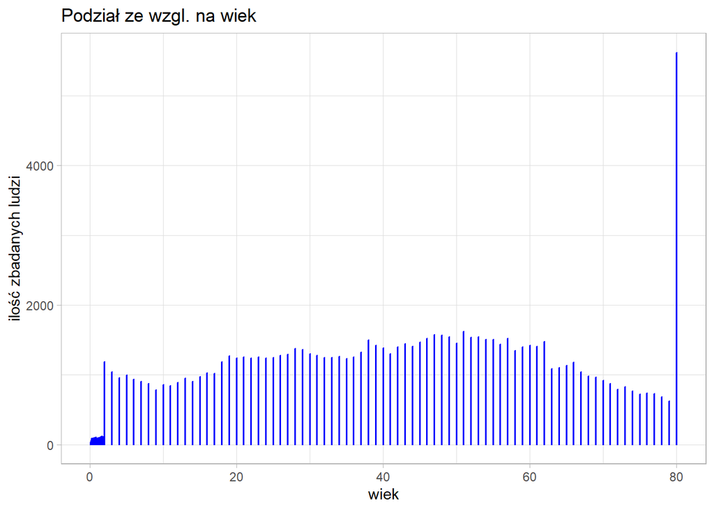

```r
C %>%
  ggplot() +
  geom_bar(aes(x = age),
           color = "blue") +
  theme_light() +
  labs(title = "Podział ze wzgl. na wiek",
       x = "wiek",
       y = "ilość zbadanych ludzi")
```

Następnie mamy zmienną jakościową hypertension (nadciśnienie):

```r
table(C$hypertension)
```

```
##
## Brak nadciśnienia      Nadciśnienie
##             92515              7485
```

Zmienna jakościowa heart_disease (choroby serca)

```r
table(C$heart_disease)
```

```
##
##     Brak choroby serca Chory na chorobę serca
##                  96058                   3942
```

Zmienna smoking_history (historia palenia)

```r
table(C$smoking_history)
```

```
##
##     current        ever      former       never     No Info not current
##        9286        4004        9352       35095       35816        6447
```

Po bliższemu przyjrzeniu się danej smoking_history, warto się zastanowić czy owa zmienna nie jest zmienną kateogryczną, mamy tu pewien stopień palenia, jednak problemem jest grupa osób “no info” oraz jak ocenić róznicę między not current, former, a ever. ciężko było by też przypisać “no Info” do którejś z grup, poniważ no info może oznaczać żę dana osoba wstydziła się powiedzieć, że dalej pali lub paliła, a może to pytanie nie było po prostu zadane danej osobie. Dlatego uznałem, że zostawie ją jako zmienną jakościową. Nie powinno to przeszkadzać w naszym pojmowaniu tej zmiennej.

Zmienna diabetes (cukrzyca):

```r
table(C$diabetes)
```

```
##
##     Brak Cukrzycy Chory na cukrzycę
##             91500              8500
```

Reszta zmiennych to ilościowe, w skrócie powiem więc, że mamy do czynienia z :  
-HbA1c_level - zmienna która pokazuje nam średni poziom cukru sprzed 2-3 miesięcy (bo tyle średnio żyje krwinka czerwona we krwi). Przyjęto, że poziom HbA1c powyżej 6.5 wskazuje na cukrzycę.  
-blood_glucose_level - poziom glukozy (cukru) we krwi w trakcie przeprowadzania badania.

Sprawdzmy jeszcze raz podstawowe statystyki opisowe, jednak tym razem, tylko dla zmiennych ilościowych.

```r
C %>%
  select(age,bmi, HbA1c_level, blood_glucose_level) %>%
  describe()
```

```
##                     vars     n   mean    sd median trimmed   mad   min    max
## age                    1 1e+05  41.89 22.52  43.00   42.00 26.69  0.08  80.00
## bmi                    2 1e+05  27.32  6.64  27.32   26.91  4.51 10.01  95.69
## HbA1c_level            3 1e+05   5.53  1.07   5.80    5.57  1.19  3.50   9.00
## blood_glucose_level    4 1e+05 138.06 40.71 140.00  134.88 28.17 80.00 300.00
##                      range  skew kurtosis   se
## age                  79.92 -0.05    -1.00 0.07
## bmi                  85.68  1.04     3.52 0.02
## HbA1c_level           5.50 -0.07     0.22 0.00
## blood_glucose_level 220.00  0.82     1.74 0.13
```

```
##  /\     /\
## {  `---'  }
## {  O   O  }
## ==>  V <==  No need for mice. This data set is completely observed.
##  \  \|/  /
##   `-----'
```

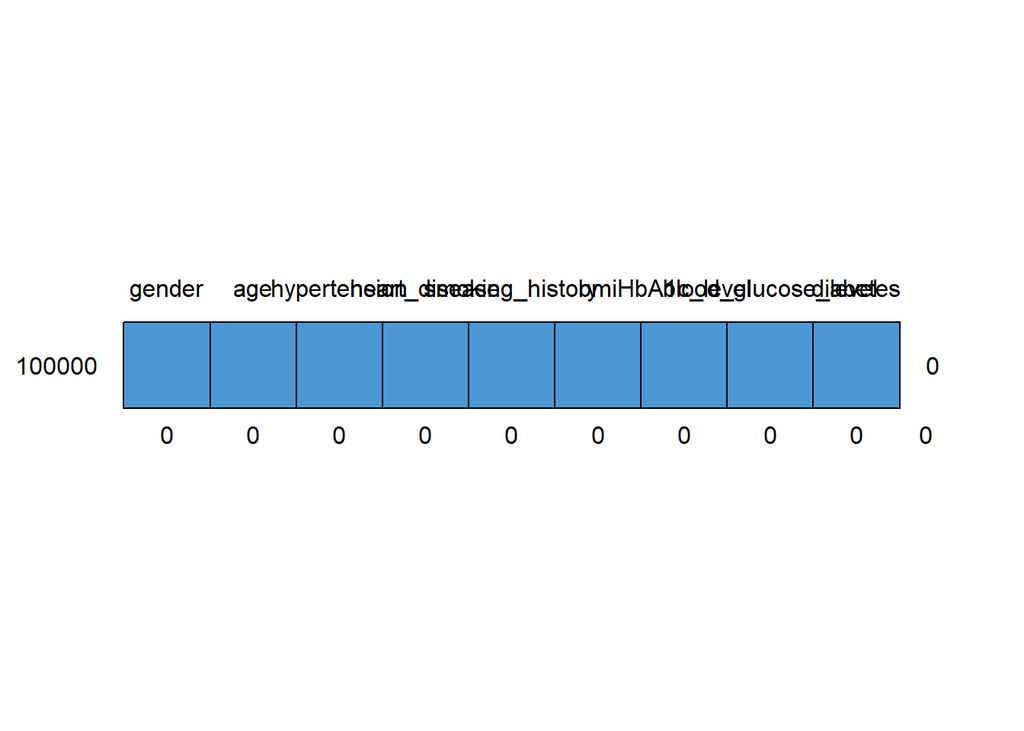

```
##        gender age hypertension heart_disease smoking_history bmi HbA1c_level
## 100000      1   1            1             1               1   1           1
##             0   0            0             0               0   0           0
##        blood_glucose_level diabetes
## 100000                   1        1 0
##                          0        0 0
```

```r
md.pattern(C)
```

Na pewno wiemy, że nie mamy do czynienia z brakami danych, co nas cieszy. Co jednak z wartościami odstającymi? Widzimy że exces bmi wynosi aż 3.52, przyjrzyjmy się tej zmiennej

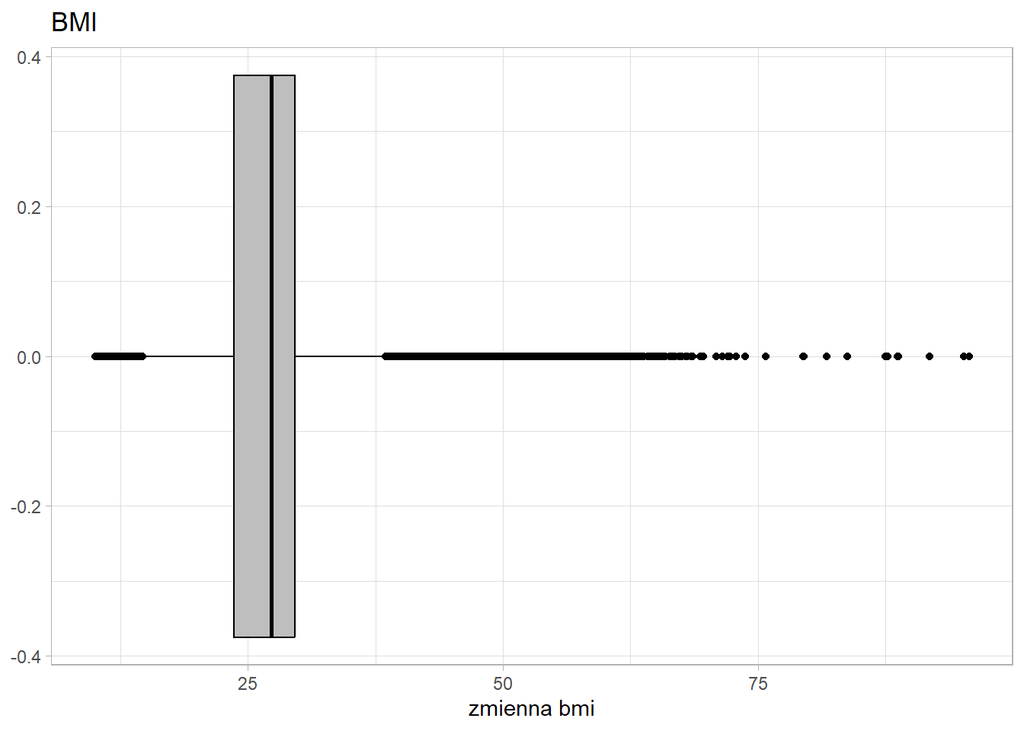

```r
C %>%
  ggplot() +
  geom_boxplot(aes(x = bmi),
               color = "black", fill = "grey") +
  theme_light() +
  labs(title = "BMI",
       x = "zmienna bmi")
```

Pomimo wielu “kropek” symbolizujących dane odstające musimy pamiętać, że danych jest aż 100 tys. dlatego też, spójrzmy na zwykły wykres

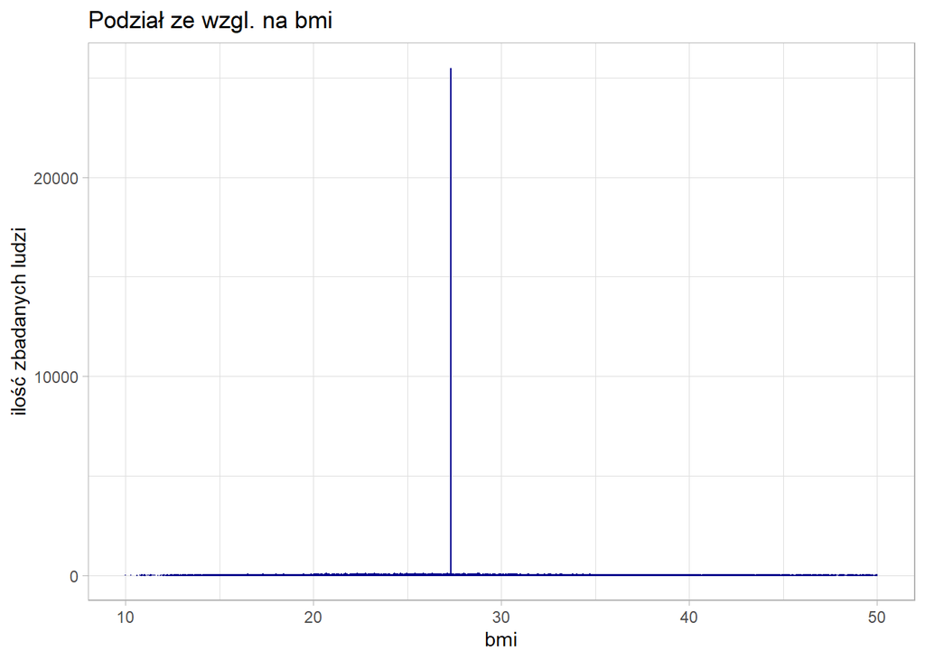

```r
C %>%
filter(bmi<50) %>%
  ggplot() +
  geom_bar(aes(x = bmi),
           color = "darkblue", fill = "lightblue") +
  theme_light() +
  labs(title = "Podział ze wzgl. na bmi",
       x = "bmi",
       y = "ilość zbadanych ludzi")
```

Oraz funkcje summary

```r
summary(C$bmi)
```

```
##    Min. 1st Qu.  Median    Mean 3rd Qu.    Max.
##   10.01   23.63   27.32   27.32   29.58   95.69
```

# Pytania Badawcze

## 1.Czy płeć ma wpływ na zachorowanie na cukrzycę?

Na początku przedstawmy dane w tabeli:

```r
table(C$gender,C$diabetes)
```

```
##
##          Brak Cukrzycy Chory na cukrzycę
##   Female         54091              4461
##   Male           37391              4039
##   Other             18                 0
```

Diabetyków w obu płaciach wydaje się podobna ilość, jednak przebadanych kobiet jest znacznei więcej, spójrzmy jeszcze na wykres:

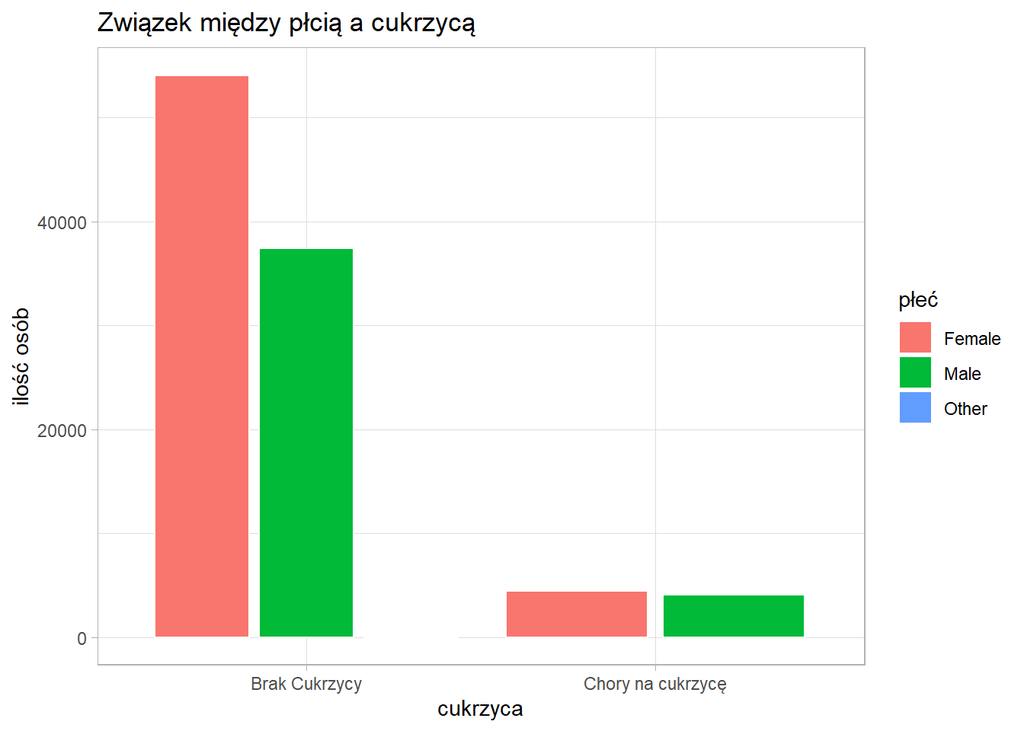

```r
C %>%
  ggplot() +
  geom_bar(aes(x = diabetes, fill = gender),
           color = "white",
           position = "dodge2") +
  theme_light() +
  labs(title = "Związek między płcią a cukrzycą",
       x = "cukrzyca",
       y = "ilość osób",
       fill = "płeć")
```

## 2.Czy palenie papierosów ma coś związanego z cukrzycą?

Ponownie na początku przedstawmy dane w tabeli

```r
table(C$smoking_history, C$diabetes)
```

```
##
##               Brak Cukrzycy Chory na cukrzycę
##   current              8338               948
##   ever                 3532               472
##   former               7762              1590
##   never               31749              3346
##   No Info             34362              1454
##   not current          5757               690
```

Nic nie pokaże lepiej zależności między dwoma zmiennymi jakościowymi niż wykres:

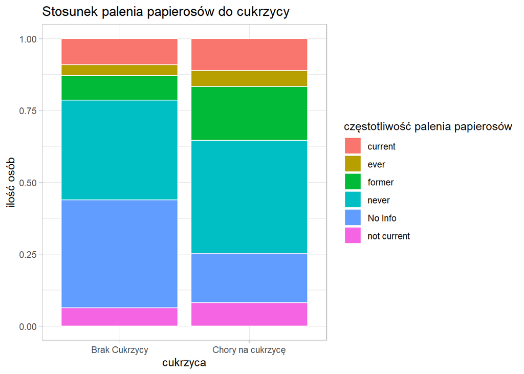

```r
C %>%
  ggplot() +
  geom_bar(aes(x = diabetes, fill = smoking_history),
           color = "white",
           position = "fill") +
  theme_light() +
  labs(title = "Stosunek palenia papierosów do cukrzycy",
       x = "cukrzyca",
       y = "ilość osób",
       fill = "częstotliwość palenia papierosów")
```

Wnioski które możemy wyciągnąć z powyższych danych są następujące:  
- grupa “no Info” znacznie skurczyłą się w przypadku grupy osób z cukrzycą.  
- grupa “former” znacznie wzrosła, ponadto mały wzrost grupy current oraz not current.  
Więc czy z powyższych danych wynika, że palenie papierosów jest powiązane z chorowaniem na cukrzycę? - ciężko powiedzieć. Wskazówką dla nas jest grupa osób, która nigdy nie paliła papierosów, ta grupa również wzrosła w przypadku prawego słupka. Mogłoby to sugerować, że palenie nie ma związku z częstotliwością chorowania na cukrzycę.

## 3.Związek między chorobami serca, a cukrzycą

```r
table(C$heart_disease,C$diabetes)
```

```
##
##                          Brak Cukrzycy Chory na cukrzycę
##   Brak choroby serca             88825              7233
##   Chory na chorobę serca          2675              1267
```

Po zobaczeniu samych danych w tabelce łatwo jest stwierdzić, że choroby serca częściej towarzyszą osobom z cukrzycą, narysujmy wykres, który to potwierdzi

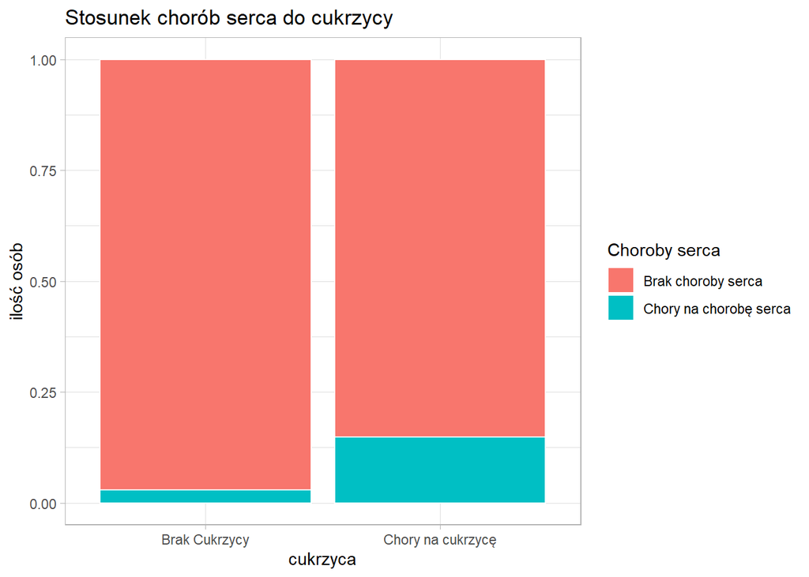

```r
C %>%
  ggplot() +
  geom_bar(aes(x = diabetes, fill = heart_disease),
           color = "white",
           position = "fill") +
  theme_light() +
  labs(title = "Stosunek chorób serca do cukrzycy",
       x = "cukrzyca",
       y = "ilość osób",
       fill = "Choroby serca")
```

Z całą pewnością możemy potwierdzić, żę osoby chorujące na cukrzycę, częściej chorują również na choroby serca niż osoby zdrowe. Nie możemy jednak stwierdzić, który czynnik jest zależny od drugiego.

## 4.Związek między nadciśnieniem, a cukrzycą

```r
table(C$diabetes,C$hypertension)
```

```
##
##                     Brak nadciśnienia Nadciśnienie
##   Brak Cukrzycy                 86103         5397
##   Chory na cukrzycę              6412         2088
```

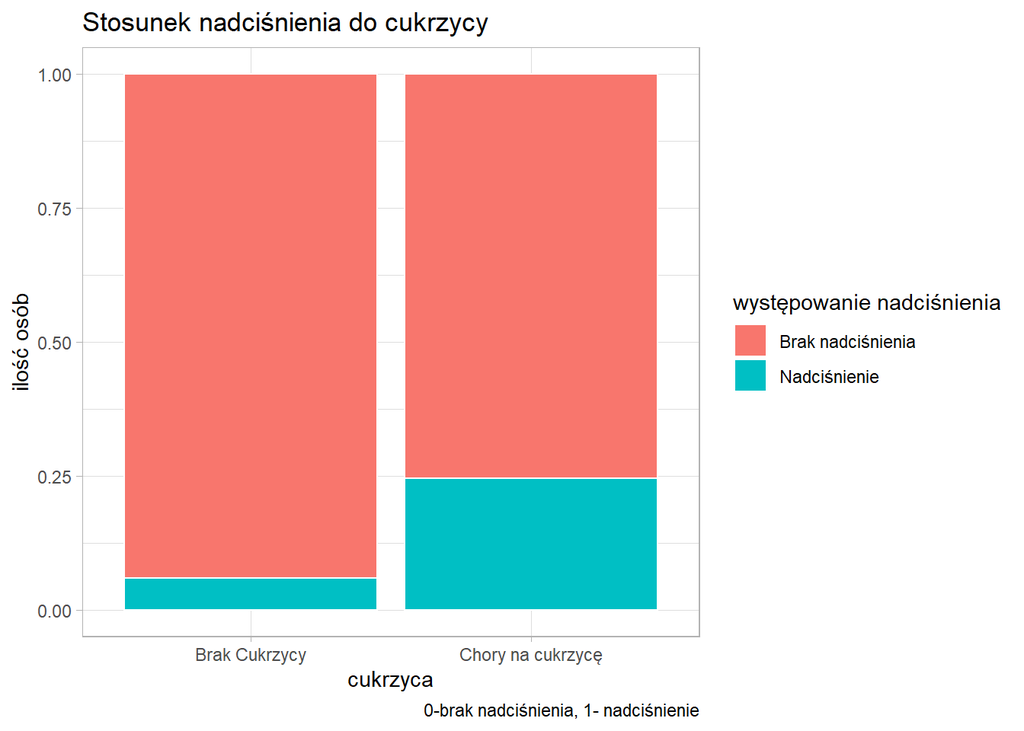

```r
C %>%
  ggplot() +
  geom_bar(aes(x = diabetes, fill = hypertension),
           color = "white",
           position = "fill") +
  theme_light() +
  labs(title = "Stosunek nadciśnienia do cukrzycy",
       caption = "0-brak nadciśnienia, 1- nadciśnienie",
       x = "cukrzyca",
       y = "ilość osób",
       fill = "występowanie nadciśnienia")
```

Po zobaczeniu danych oraz wykresu wysuwam podobny wniosek, co przy chorobach serca, osoby chorujące na cukrzycę częściej chorują również na nadciśnienie, niż osoby zdrowe.

## 5.W związku z powyższym pytaniem nasuneła mi się myśl, czy choroby serca są związane z nadciśnieniem?

```r
table(C$hypertension,C$heart_disease)
```

```
##
##                     Brak choroby serca Chory na chorobę serca
##   Brak nadciśnienia              89489                   3026
##   Nadciśnienie                    6569                    916
```

Możemy zsprawdzić stopień korelacji za pomocą współczynnika V-Cramera

```r
assocstats(table(C$hypertension,C$heart_disease))$cramer
```

```
## [1] 0.1212617
```

Korelacja wyszła bardzo niska, jednak jeśli spojrzymy na wykres:

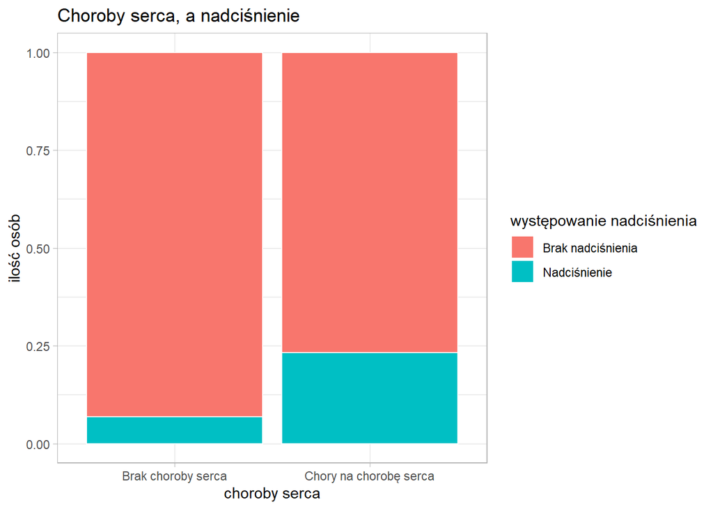

```r
C %>%
  ggplot() +
  geom_bar(aes(x = heart_disease, fill = hypertension),
           color = "white",
           position = "fill") +
  theme_light() +
  labs(title = "Choroby serca, a nadciśnienie",
       x = "choroby serca",
       y = "ilość osób",
       fill = "występowanie nadciśnienia")
```

To jasno widać, że osoby chorujące na chorobę serca, częściej mają nadciśnienie niż osoby nie posiadające chorób serca.

## 6.Związek między bmi a cukrzycą

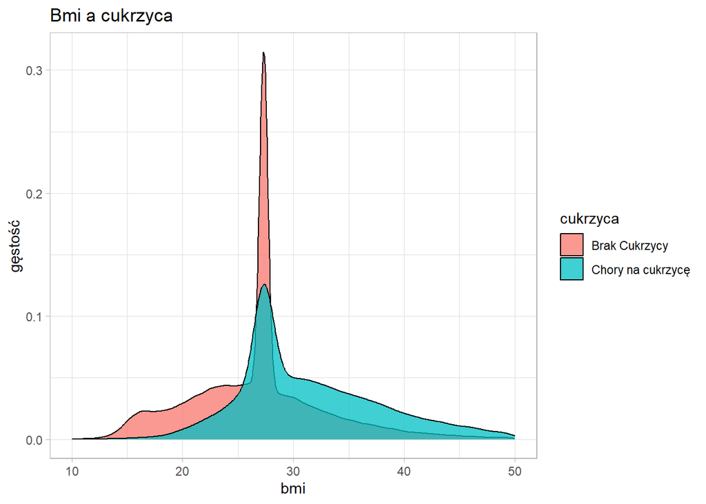

```r
C %>%
  filter(bmi<50) %>%
  ggplot() +
  geom_density(aes(x = bmi, fill = diabetes), alpha = 0.75) +
  theme_light() +
  labs(title = "Bmi a cukrzyca",
       x = "bmi",
       y = "gęstość",
       fill = "cukrzyca")
```

Ograniczyłem bmi do 50 dla większej czytelności wykresu. Bmi jest to wkaźnik liczony poprzez wzrost oraz wagę, który w astronomicznym skrócie wskazuje na stopień otyłości danej osoby. Bmi ok. 25 jest bmi normalnym, bmi powyżej 30 zaczyna wskazywać na pewien stopień otyłości, tym więcej tym większa otyłość, z kolei bmi poniżej 20 wskazuje na niedowagę. Z wykresu wyciągamy wniosek, że osoby chorujące na cukrzycę mają znacznie większe Bmi niż zdrowa część społeczeństwa. Można więc powiedzieć, że statstycznie są one bardziej otyłe.

## 7.Związek między HbA1c a cukrzycą

```r
table(C$HbA1c_level, C$diabetes)
```

```
##
##       Brak Cukrzycy Chory na cukrzycę
##   3.5          7662                 0
##   4            7542                 0
##   4.5          7585                 0
##   4.8          7597                 0
##   5            7471                 0
##   5.7          7709               704
##   5.8          7662               659
##   6            7648               647
##   6.1          7397               651
##   6.2          7621               648
##   6.5          7749               613
##   6.6          7857               683
##   6.8             0               642
##   7               0               634
##   7.5             0               643
##   8.2             0               661
##   8.8             0               661
##   9               0               654
```

Z samej tabelki dochodzimy do ciekawego wniosku, nie ma osób chorych na cukrzycę z hbA1c na poziomie 5 lub niższym oraz nie ma osób zdrowych na poziomie HbA1c wyższym niż 6.8

Spróbujmy to narysować na wykresie.

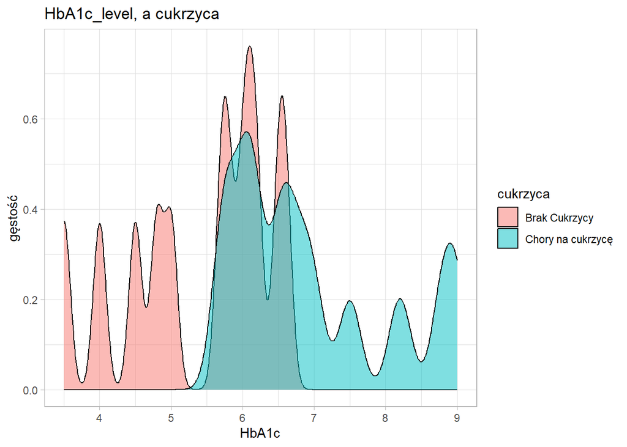

```r
C %>%
  ggplot() +
  geom_density(aes(x = HbA1c_level, fill = diabetes), alpha = 0.5)   +
  theme_light() +
  labs(title="HbA1c_level, a cukrzyca",
       x="HbA1c",
       y="gęstość",
       fill="cukrzyca")
```

Co ciekawe, w opisie zestawu danych, było napisane, że osoba z HbA1c na poziomie 6.5 lub wyższym to pawie na pewno diabetyk, a patrząc na dane jest sporo osób zdrowych z takim poziomem, a nawet z poziomem 6.6, granica pojawia się od HbA1c równego 6.8

## 8.Związek między poziomem cukru we krwi w chwili badania, a cukrzycą,

Pozwolę sobie przyjąc hipotezę badawczą, bazując na doświadczeniu empirycznym, że cukier zdrowej osoby nigdy nie powinien przekroczyć 140 jednostek w chwili badania

```r
table(C$blood_glucose_level,C$diabetes)
```

```
##
##       Brak Cukrzycy Chory na cukrzycę
##   80           7106                 0
##   85           6901                 0
##   90           7112                 0
##   100          7025                 0
##   126          7066               636
##   130          7102               692
##   140          7107               625
##   145          7017               662
##   155          6976               599
##   158          7026                 0
##   159          7093               666
##   160          7016               696
##   200          6953               647
##   220             0               603
##   240             0               636
##   260             0               635
##   280             0               729
##   300             0               674
```

Moją uwagę przykuł fakt, że maksymalny poziom cukru wynosi 300, a minimalny 80. Sugeruje to, że dane zostały na pewnym etapie wstępnie okrojone lub do wartości granicznych zostały dodane dane wykraczające, podobnie jak przy wieku.  
Faktem jest, że cukier może podskoczyć do wiele wyższych wartości (nawet 600 jednostek).

Nie mogę też pominąć faktu dziwnego rozłożenia danych pozyskanych podczas mierzenia poziomu glukozy. Przy 100 000 obserwacjach dane nie powinny iść schodkowo, każdy poziom cukru przynajmniej powinien się pojawić chociaż raz. Tak nienaturalne skoki mogą świadczyć o pewnych nieprawidłowościach związanych z narzędziem do pomiaru.  
Narysujmy wykres gęstości, powinien nas on upewnić w kilku rzeczach.

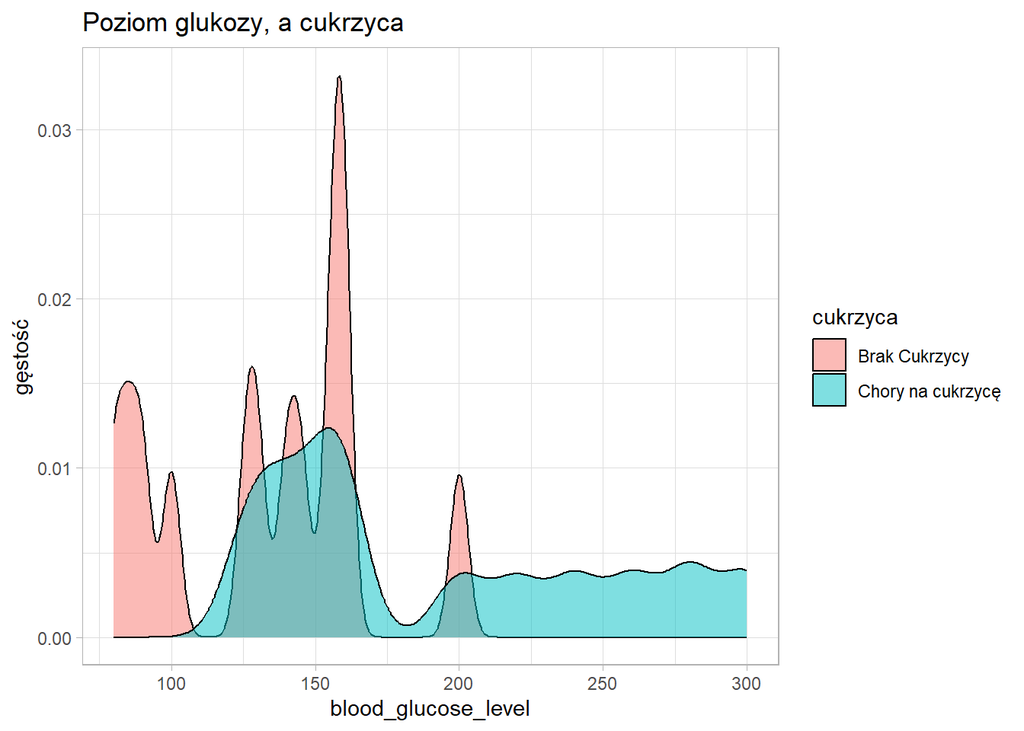

```r
C %>%
  ggplot() +
  geom_density(aes(x = blood_glucose_level, fill = diabetes), alpha = 0.5)   +
  theme_light() +
  labs(title="Poziom glukozy, a cukrzyca",
       x="blood_glucose_level",
       y="gęstość",
       fill="cukrzyca")
```

Przyjrzyjmy się jeszcze dokładniej danym

```r
summary(C$blood_glucose_level)
```

```
##    Min. 1st Qu.  Median    Mean 3rd Qu.    Max.
##    80.0   100.0   140.0   138.1   159.0   300.0
```

Ciekawym wnioskiem, który możemy wyciągnać z tego wykresu jest faky, że odpowiedni poziom cukru (80,140) wcale nie upewnia nas w fakcie, że jesteśmy zdrowi, znaczna ilość osób z cukrem z zakresu (126,140) to diabetycy. Nie możemy jednak przemilczeć faktu, że zgodnie z naszymi danymi, osoby z cukrem <= 100 to zawsze osoby zdrowe. A osoby z cukrem powyżej 200 są w 100% osobami chorymi.

## 9.Wiek a cukrzyca.

Zastanawiam czy się ryzyko zachorowania na cukrzycę zwiększa się wraz z wiekiem. Problem polega na tym, że nie odpowiemy na to pytanie, bo dana osoba mogła zachorować znacznie wcześniej. Zamiast tego możemy zobaczyć, w jakim wieku jest najwięcej osób z cukrzycą i z tego spróbować coś wnioskować.

```r
table(C$age,C$diabetes)
```

```
##
##        Brak Cukrzycy Chory na cukrzycę
##   0.08            36                 0
##   0.16            59                 0
##   0.24            87                 0
##   0.32            89                 0
##   0.4             66                 0
##   0.48            83                 0
##   0.56            96                 0
##   0.64            99                 0
##   0.72           104                 0
##   0.8            102                 0
##   0.88            90                 0
##   1               83                 0
##   1.08            95                 0
```

[output cut: 89 more lines]

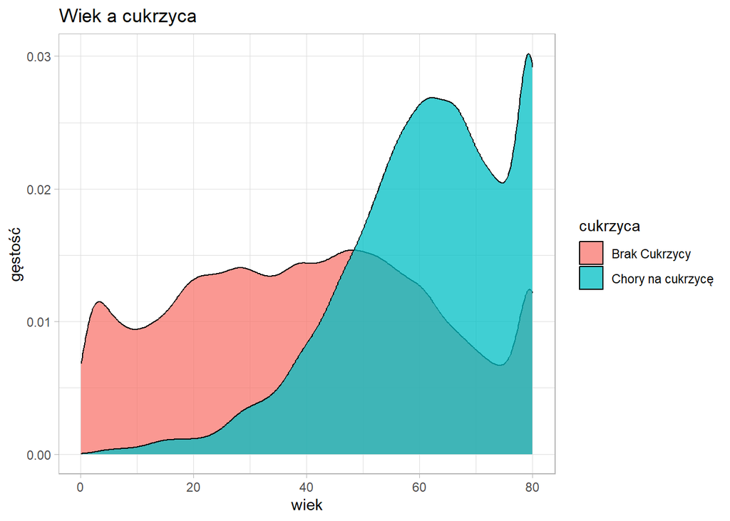

```r
C %>%
  ggplot() +
  geom_density(aes(x = age, fill = diabetes), alpha = 0.75) +
  theme_light() +
  labs(title = "Wiek a cukrzyca",
       x = "wiek",
       y = "gęstość",
       fill = "cukrzyca")
```

Wykres jednoznacznie pokazuje nam, że przynajmniej w momencie badania, większość osób z cukrzycą to osoby starsze. Nie wskazuje to wprost na to, że oosby starsze ciężej chorują. Posiadając jednak wiedzę, że cukrzyca jest chorobą nieuleczalną, możemy wnioskować, że w przypadku gdyby osoby młode i starsze miały podobne szanse na zachorowanie wykres nie powinien mieć takiej asymetrii.  
Reasumując, na podstawie wykresu wiemy z pewnością, że odsetek osób starszych (>40) chorujących na cukrzycę jest znacznie większy niż wśród osób młodszych (<40) oraz z pewną dozą ostrożności, można stwierdzić, że osoby starsze są objęte większym ryzykiem zachorowania na cukrzycę niż grupa młodsza

# Podsumowanie

Słowem końca, ten zestaw danych powstał w celu próby przewidzenia jakie czynniki wpływają na występowanie cukrzycy, więc właśnie takie pytania zadawałem. Szczerze zdziwiły mnie niektóre powiązania lub ich brak w miejscu gdzie je zakładałem. Na przykład byłem pewien że palenie papierosów powinno wpłynąć na chorowanie na cukrzycę albo, że osoby zdrowe zawsze mają cukier w przedziale <80,140>. Zauważyliśmy, że na cukrzycę wpływają takie czynniki jak:

- Wiek (osoby starsze)
- płeć (mężczyźni)
- nadciśnienie
- choroby serca
- HbA1c_level (powyżej normy)
- glukoza we krwi (powyżej normy)
- bmi (powyżej normy)  
  Pewnym jest, że przy cukrzycy wyżej wymienione zjawiska częściej występują, jednak nie możemy stwierdzić, że właśnie one cukrzycę wywołały. Trzeba przyznać, że ktoś kto stworzył ten zestaw danych miał całkiem dobrego nosa co może się przydać.

Dziękuję za lekturę mojej pracy, Tomasz Sałapatek